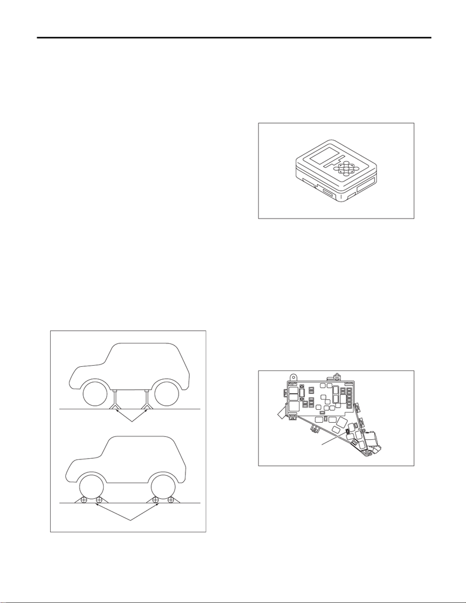

EN(STI)(diag)-46

Inspection Mode

ENGINE (DIAGNOSTICS)

1. PREPARATION FOR THE INSPECTION

MODE

1) Check that the battery voltage is 12 V or more

and fuel remains approx. half [20 — 40 L (5.3 —

10.6 US gal, 4.4 — 8.8 Imp gal)].

2) Lift up the vehicle using a garage jack and place

it on rigid racks, or drive the vehicle onto free roll-

ers.

WARNING:

• Before lifting up the vehicle, ensure parking

brake is applied.

• Do not use a pantograph jack in place of a rig-

id rack.

• Secure a rope or wire to the front or rear tow-

ing hooks to prevent the lateral runout of front

wheels.

• Before rotating the wheels, make sure that

there is no one in front of the vehicle. Besides

while the wheels are rotating, make sure that no

one approaches the vehicle front side.

• Make sure that there is nothing around the

wheels. For AWD model, pay attention to all

four wheels.

• While servicing, do not depress or release

the clutch pedal or accelerator pedal quickly re-

gardless of the engine speed. Quick operation

may cause the vehicle to drop off the free roller.

• To prevent the vehicle from slipping due to

vibration, do not place anything between rigid

rack and the vehicle.

2. SUBARU SELECT MONITOR

1) Check that no DTC remains after clearing mem-

ory. <Ref. to EN(STI)(diag)-59, Clear Memory

Mode.>

2) Warm up the engine.

3) Prepare the Subaru Select Monitor kit. <Ref. to

EN(STI)(diag)-7, PREPARATION TOOL, General

Description.>

4) Prepare PC with Subaru Select Monitor in-

stalled.

5) Connect the USB cable to SDI (Subaru Diagno-

sis Interface) and USB port on the personal com-

puter (dedicated port for the Subaru Select

Monitor).

NOTE:

The dedicated port for the Subaru Select Monitor

means the USB port which was used to install the

Subaru Select Monitor.

6) Connect the diagnosis cable to SDI.

7) Install the delivery mode fuse (A).

CAUTION:

Do not use any fuses that are installed on the

vehicle.

(A) Rigid rack

(B) Free roller

EN-00041

(A)

(B)

EN-05692

EN-10881

(A)

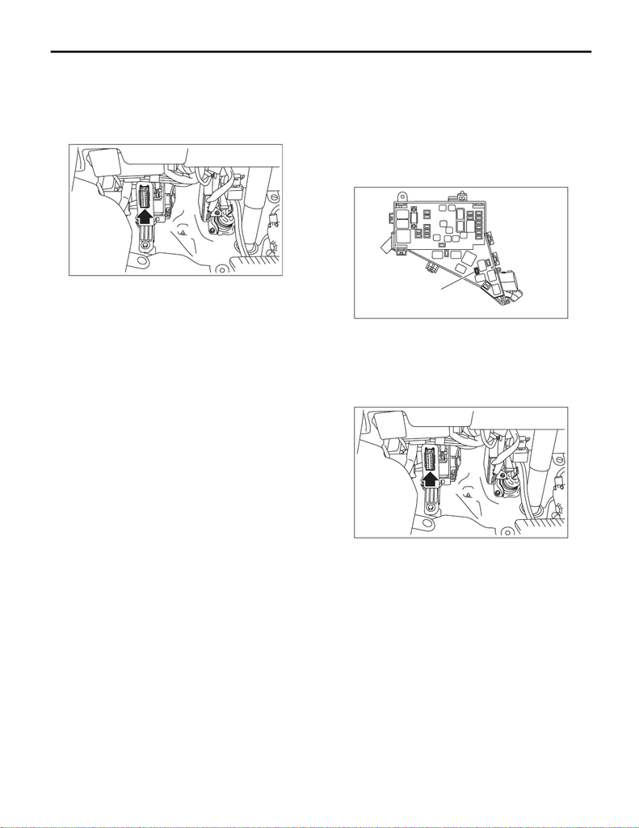

EN(STI)(diag)-47

Inspection Mode

ENGINE (DIAGNOSTICS)

8) Connect SDI to data link connector located in the

lower portion of the instrument panel (on the driv-

er’s side).

CAUTION:

Do not connect the scan tools except for Suba-

ru Select Monitor and general scan tool.

9) Start the PC.

10) Turn the ignition switch to ON (engine OFF)

and run the “PC application for Subaru Select Mon-

itor”.

11) On «Main Menu» display, select {Each System

Check}.

12) On «System Selection Menu» display, select

{Engine Control System}.

13) Click the [OK] button after the information of

engine type has been displayed.

14) On «Engine Diagnosis» display, select {Dealer

Check Mode Procedure}.

15) When the “Perform Inspection (Dealer Check)

Mode ?” is shown on the screen, click the [Next]

button.

16) Perform subsequent procedures as instructed

on the display screen.

• If trouble still remains in the memory, the corre-

sponding DTC appears on the display screen.

NOTE:

• For detailed operation procedures, refer to

“PC application help for Subaru Select Monitor”.

• For details concerning DTC, refer to “List of Di-

agnostic Trouble Code (DTC)”.

<Ref. to EN(STI)(diag)-86, List of Diagnostic

Trouble Code (DTC).>

• Release the parking brake.

• The rotating speed difference between front

and rear wheels may illuminate the ABS warning

light, but this does not indicate a malfunction.

When engine control system diagnosis is fin-

ished, perform the VDC memory clearance pro-

cedure of self-diagnosis function. <Ref. to

VDC(diag)-23, Clear Memory Mode.>

3. GENERAL SCAN TOOL

1) Check that no DTC remains after clearing mem-

ory. <Ref. to EN(STI)(diag)-59, Clear Memory

Mode.>

2) Warm up the engine.

3) Install the delivery mode fuse (A).

CAUTION:

Do not use any fuses that are installed on the

vehicle.

4) Connect the general scan tool to data link con-

nector located in the lower portion of the instrument

panel (on the driver’s side).

CAUTION:

Do not connect the scan tools except for Suba-

ru Select Monitor and general scan tool.

5) Start the engine.

NOTE:

Depress the clutch pedal when starting engine.

6) Turn the neutral position switch to ON by operat-

ing shift lever.

7) Keep the engine speed in 2,500 — 3,000 rpm

range for 40 seconds.

8) Place the shift lever in 1st gear and drive the ve-

hicle at 5 to 10 km/h (3 to 6 MPH).

NOTE:

• For AWD model, release the parking brake.

• The rotating speed difference between front and

rear wheels may illuminate the ABS warning light,

but this does not indicate a malfunction. When en-

gine control system diagnosis is finished, perform

the VDC memory clearance procedure of self-diag-

nosis function. <Ref. to VDC(diag)-23, Clear Mem-

ory Mode.>

EN-09145

EN-10881

(A)

EN-09145

[figure not shown]

EN(STI)(diag)-48

Inspection Mode

ENGINE (DIAGNOSTICS)

9) Using the general scan tool, check for DTC and

record the result(s).

NOTE:

• For detailed operation procedures, refer to the

general scan tool operation manual.

• For details concerning DTC, refer to “List of Diag-

nostic Trouble Code (DTC)”.

<Ref. to EN(STI)(diag)-86, List of Diagnostic Trou-

ble Code (DTC).>